# Last Session Recap

Published

Monday, 08/01/2024

# 1 Preamble

## 1.1 Library & Data

````markdown
```{r}
pacman::p_load(tidyverse, haven, summarytools)
```
````

**Please check you have the latest R and RStudio**

# 2 Recap

## 2.1 Introduction

1. What is R?
- programming language and environment commonly used for statistical computing and graphics.
- provides an extensive array of statistical and graphical techniques
- highly extensible, allowing users to create new functions and contribute packages
- popular choice for data analysis and research in various scientific disciplines

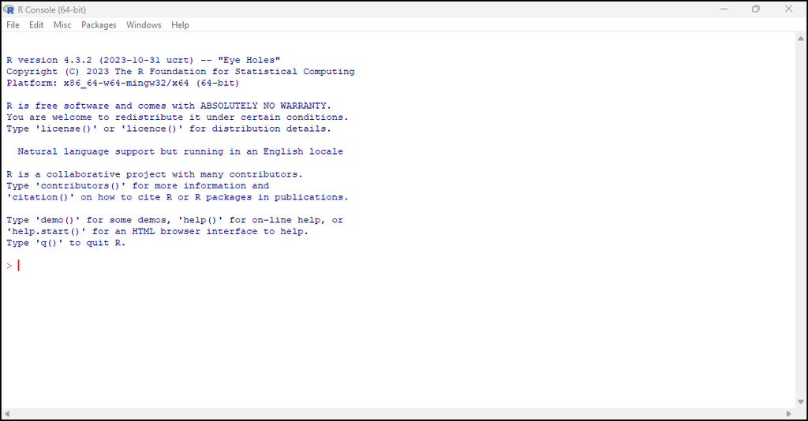

R Main Window

2. What is RStudio?
- an IDE (integrated development environment) for R (and other languages too!)
- provide user-friendly interface with tools for script editing, data visualization, debugging and project management
- if R is the engine, RStudio is the car

[figure not shown]

RStudio Main Window

3. What is Quarto?
- open-source scientific and technical publishing system
- allow user to create **dynamic report**, presentation and publication
- support multiple language including R, Python, Julia
- integrate with RStudio, Juptyer
4. Using R (and RStudio), Quarto allow for
- weave seamlessly narrative text and R code within document
- produce elegantly formatted output: live analysis result, visualisation

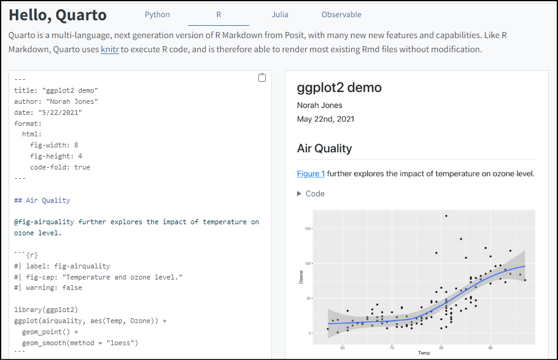

Quarto Example

## 2.2 Introduction Practical

### 2.2.1 Basic R and some concepts related

1. Open your `R`
2. R allow for mathematical operation
- enter `1 + 2` in your consoles, and press enter
- try any other mathematical operation
3. R recognised various data type
- number, e.g. `1`, `2`. use `class(_)` function to check data type
- string/character. need `"` symbols. e.g. `"car"`, `"orange"`, `"male"`
4. We can “store” items in object
- enter `one`, then write 1 into object name one `one <- 1`, then call back the object `one`
- write array e.g. list of numbers `list_num <- c(1,2,3)`
- write array e.g. list of strings `my_cars <- c("merc", "bimmer", "supra")`
5. Close your `R` (Ctrl+Q)

### 2.2.3 Basic R Script

**Note**

- I didn’t teach this previously, because I skip to Quarto.
- My 1st class in R does not cover R script, we went straight to RMarkdown (the precursor for Quarto)
- At first, I want to skip this altogether, but when I think back, teach R script may provide context need when writing Quarto
1. R scrip allow us to save the syntax
2. Open Project
3. Create new R script
- File -> New File… -> R Scrip (Ctrl+Shift+N)
4. Write the syntax

```r
1
1 + 2
one <- 1
list_num <- c(1,2,3)
my_cars <- c("merc", "bimmer", "supra")
```

5. You can run line by line (Ctrl+Enter) or source everything (Ctrl+Shift+Enter)

### 2.2.4 Basic Quarto

1. Create quarto file
- File -> New File -> Quarto Document
- Enter Title, e.g. “Data Visualisation”
- Create Empty Document
2. Edit YAML
- `embed-resources: true`

```
---
title: "Data Visualisation"
format:
  html:
    embed-resources: true
---
```

3. Write the syntax

```r
1
1 + 2
one <- 1
list_num <- c(1,2,3)
my_cars <- c("merc", "bimmer", "supra")
```

## 2.3 Data Wrangling

1. 80-90% of data analysis consist of data cleaning

2. Example 1: Import Dataset - SPSS

````markdown
```{r}
library(haven)

asthmads_savh <- haven::read_sav("../dataset/asthma_ds.sav") # also achieve same
asthmads_savh <- haven::as_factor(asthmads_savh)
asthmads_savh
```
````

| id | idR | Gender | Age | Height | Weight_Pre | PA_HW | Weight_Post | Tx2 | PEFR_Pre | PEFR_Post | SxWheeze_Pre | SxWheeze_Post | PS_Pre | PS_Post |
| --- | --- | --- | --- | --- | --- | --- | --- | --- | --- | --- | --- | --- | --- | --- |
| 1 | 8pg4 | Female | 34 | 134 | 47.5 | 3 | 42.4 | Drug B | 434 | 428 | No | No | 5 | 5 |
| 2 | VOPL | Male | 31 | 161 | 59.8 | 8 | 49.4 | Drug A | 484 | 525 | Yes | No | 6 | 5 |
| 3 | Y3Gs | Male | 25 | 184 | 91.2 | 3 | 78.3 | Drug A | 464 | 525 | Yes | Yes | 5 | 5 |
| 4 | 0vTK | Female | 33 | 141 | 60.4 | 2 | 53.4 | Drug B | 434 | 521 | No | No | 5 | 4 |
| 5 | jNUd | Male | 28 | 174 | 96.4 | 1 | 88.1 | Drug A | 484 | 560 | Yes | No | 5 | 4 |
| 6 | ax87 | Male | 33 | 189 | 76.4 | 0 | 70.3 | Placebo | 474 | 471 | Yes | Yes | 6 | 6 |
| 7 | Hndi | Female | 31 | 172 | 58.2 | 4 | 47.5 | Drug A | 394 | 438 | Yes | No | 4 | 4 |
| 8 | YCkg | Female | 34 | 159 | 52.8 | 3 | 47.0 | Drug A | 426 | 515 | Yes | No | 4 | 4 |
| 9 | aJX5 | Male | 31 | 192 | 83.5 | 4 | 70.0 | Drug B | 447 | 515 | Yes | No | 5 | 4 |
| 10 | d5NA | Male | 28 | 168 | 60.4 | 2 | 52.8 | Placebo | 427 | 471 | Yes | No | 4 | 4 |

[output cut: 140 more lines]

3. Example 2: Import Dataset - CSV

````markdown
```{r}
asthma_ds0 <- read.csv("../dataset/asthma_ds_nolab.csv")
asthma_ds0
```
````

| idR | Gender | Age | Height | Weight_Pre | PA_HW | Weight_Post | Tx2 | PEFR_Pre | PEFR_Post | SxWheeze_Pre | SxWheeze_Post | PS_Pre | PS_Post |
| --- | --- | --- | --- | --- | --- | --- | --- | --- | --- | --- | --- | --- | --- |
| 8pg4 | 2 | 34 | 134 | 47.5 | 3 | 42.4 | 3 | 434 | 428 | 1 | 1 | 5 | 5 |
| VOPL | 1 | 31 | 161 | 59.8 | 8 | 49.4 | 2 | 484 | 525 | 2 | 1 | 6 | 5 |
| Y3Gs | 1 | 25 | 184 | 91.2 | 3 | 78.3 | 2 | 464 | 525 | 2 | 2 | 5 | 5 |
| 0vTK | 2 | 33 | 141 | 60.4 | 2 | 53.4 | 3 | 434 | 521 | 1 | 1 | 5 | 4 |
| jNUd | 1 | 28 | 174 | 96.4 | 1 | 88.1 | 2 | 484 | 560 | 2 | 1 | 5 | 4 |
| ax87 | 1 | 33 | 189 | 76.4 | 0 | 70.3 | 1 | 474 | 471 | 2 | 2 | 6 | 6 |
| Hndi | 2 | 31 | 172 | 58.2 | 4 | 47.5 | 2 | 394 | 438 | 2 | 1 | 4 | 4 |
| YCkg | 2 | 34 | 159 | 52.8 | 3 | 47.0 | 2 | 426 | 515 | 2 | 1 | 4 | 4 |
| aJX5 | 1 | 31 | 192 | 83.5 | 4 | 70.0 | 3 | 447 | 515 | 2 | 1 | 5 | 4 |
| d5NA | 1 | 28 | 168 | 60.4 | 2 | 52.8 | 1 | 427 | 471 | 2 | 1 | 4 | 4 |

[output cut: 140 more lines]

4. Example 3: Select Column

````markdown
```{r}
select(asthmads_savh, idR:Weight_Post)
```
````

| idR | Gender | Age | Height | Weight_Pre | PA_HW | Weight_Post |
| --- | --- | --- | --- | --- | --- | --- |
| 8pg4 | Female | 34 | 134 | 47.5 | 3 | 42.4 |
| VOPL | Male | 31 | 161 | 59.8 | 8 | 49.4 |
| Y3Gs | Male | 25 | 184 | 91.2 | 3 | 78.3 |
| 0vTK | Female | 33 | 141 | 60.4 | 2 | 53.4 |
| jNUd | Male | 28 | 174 | 96.4 | 1 | 88.1 |
| ax87 | Male | 33 | 189 | 76.4 | 0 | 70.3 |
| Hndi | Female | 31 | 172 | 58.2 | 4 | 47.5 |
| YCkg | Female | 34 | 159 | 52.8 | 3 | 47.0 |
| aJX5 | Male | 31 | 192 | 83.5 | 4 | 70.0 |
| d5NA | Male | 28 | 168 | 60.4 | 2 | 52.8 |

[output cut: 140 more lines]

5. Example 4: Basic Numerical Transformation

````markdown
```{r}
asthma_ds0$Ht_m <- asthma_ds0$Height/100
select(asthma_ds0, Height, Ht_m)
```
````

| Height | Ht_m |
| --- | --- |
| 134 | 1.34 |
| 161 | 1.61 |
| 184 | 1.84 |
| 141 | 1.41 |
| 174 | 1.74 |
| 189 | 1.89 |
| 172 | 1.72 |
| 159 | 1.59 |
| 192 | 1.92 |
| 168 | 1.68 |

[output cut: 140 more lines]

6. Example 5: Binning

````markdown
```{r}
asthma_ds0$BMI_Pre <- asthma_ds0$Weight_Pre/(asthma_ds0$Ht_m^2)

asthma_ds0$BMI_PreCat <- cut(asthma_ds0$BMI_Pre,
                             breaks = c(0, 18.49, 22.99, 24.99, 100),
                             labels = c("Underweight", "Normal", "Overweight", "Obese"))

select(asthma_ds0, BMI_Pre, BMI_PreCat)
```
````

| BMI_Pre | BMI_PreCat |
| --- | --- |
| 26.45355 | Obese |
| 23.07010 | Overweight |
| 26.93762 | Obese |
| 30.38077 | Obese |
| 31.84040 | Obese |
| 21.38798 | Normal |
| 19.67280 | Normal |
| 20.88525 | Normal |
| 22.65082 | Normal |
| 21.40023 | Normal |

[output cut: 140 more lines]

7. Tidyverse allow for pipe operation.

````markdown
```{r}
asthma_ds0 <- read.csv("../dataset/asthma_ds_nolab.csv")
asthma_ds0
asthmads_clean <- asthma_ds0 %>%
  mutate(Gender = as.character(Gender),
         Gender = fct_recode(Gender, "Male" = "1", "Female" = "2"),
         Gender = fct_relevel(Gender, "Female", "Male"),
         Tx2 = fct_recode(as.character(Tx2),
                          "Placebo" = "1", "Drug A" = "2", "Drug B" = "3"),
         Tx1 = fct_collapse(Tx2,
                            "Intervention" = c("Drug A", "Drug B"),
                            "Control" = "Placebo"),
         Ht_m = Height/100,
         BMI_Pre = round(Weight_Pre/(Ht_m^2), digits = 2),
         BMI_PreCat = cut(BMI_Pre,
                          breaks = c(0, 18.49, 22.99, 24.99, 100),
                          labels = c("Underweight", "Normal", "Overweight", "Obese")),
         BMI_Post = round(Weight_Post/(Ht_m^2), digits = 2),
         BMI_PostCat = cut(BMI_Post,
                           breaks = c(0, 18.49, 22.99, 24.99, 100),
                           labels = c("Underweight", "Normal", "Overweight", "Obese")),
         across(.cols = starts_with("SxWheeze"),
                .fns = ~ as.character(.)),
         across(.cols = starts_with("SxWheeze"),
                .fns = ~ fct_recode(., "No" = "1", "Yes" = "2"))) %>%
  relocate(Tx1, .before = Tx2) %>%
  relocate(Ht_m, .after = Height) %>%
  relocate(BMI_Pre, BMI_PreCat, .after = Weight_Pre) %>%
  relocate(BMI_Post, BMI_PostCat, .after = Weight_Post)

asthmads_clean
```
````

| idR | Gender | Age | Height | Weight_Pre | PA_HW | Weight_Post | Tx2 | PEFR_Pre | PEFR_Post | SxWheeze_Pre | SxWheeze_Post | PS_Pre | PS_Post |
| --- | --- | --- | --- | --- | --- | --- | --- | --- | --- | --- | --- | --- | --- |
| 8pg4 | 2 | 34 | 134 | 47.5 | 3 | 42.4 | 3 | 434 | 428 | 1 | 1 | 5 | 5 |
| VOPL | 1 | 31 | 161 | 59.8 | 8 | 49.4 | 2 | 484 | 525 | 2 | 1 | 6 | 5 |
| Y3Gs | 1 | 25 | 184 | 91.2 | 3 | 78.3 | 2 | 464 | 525 | 2 | 2 | 5 | 5 |
| 0vTK | 2 | 33 | 141 | 60.4 | 2 | 53.4 | 3 | 434 | 521 | 1 | 1 | 5 | 4 |
| jNUd | 1 | 28 | 174 | 96.4 | 1 | 88.1 | 2 | 484 | 560 | 2 | 1 | 5 | 4 |
| ax87 | 1 | 33 | 189 | 76.4 | 0 | 70.3 | 1 | 474 | 471 | 2 | 2 | 6 | 6 |
| Hndi | 2 | 31 | 172 | 58.2 | 4 | 47.5 | 2 | 394 | 438 | 2 | 1 | 4 | 4 |
| YCkg | 2 | 34 | 159 | 52.8 | 3 | 47.0 | 2 | 426 | 515 | 2 | 1 | 4 | 4 |
| aJX5 | 1 | 31 | 192 | 83.5 | 4 | 70.0 | 3 | 447 | 515 | 2 | 1 | 5 | 4 |
| d5NA | 1 | 28 | 168 | 60.4 | 2 | 52.8 | 1 | 427 | 471 | 2 | 1 | 4 | 4 |

[output cut: 140 more lines]

| idR | Gender | Age | Height | Ht_m | Weight_Pre | BMI_Pre | BMI_PreCat | PA_HW | Weight_Post | BMI_Post | BMI_PostCat | Tx1 | Tx2 | PEFR_Pre | PEFR_Post | SxWheeze_Pre | SxWheeze_Post | PS_Pre | PS_Post |
| --- | --- | --- | --- | --- | --- | --- | --- | --- | --- | --- | --- | --- | --- | --- | --- | --- | --- | --- | --- |
| 8pg4 | Female | 34 | 134 | 1.34 | 47.5 | 26.45 | Obese | 3 | 42.4 | 23.61 | Overweight | Intervention | Drug B | 434 | 428 | No | No | 5 | 5 |
| VOPL | Male | 31 | 161 | 1.61 | 59.8 | 23.07 | Overweight | 8 | 49.4 | 19.06 | Normal | Intervention | Drug A | 484 | 525 | Yes | No | 6 | 5 |
| Y3Gs | Male | 25 | 184 | 1.84 | 91.2 | 26.94 | Obese | 3 | 78.3 | 23.13 | Overweight | Intervention | Drug A | 464 | 525 | Yes | Yes | 5 | 5 |
| 0vTK | Female | 33 | 141 | 1.41 | 60.4 | 30.38 | Obese | 2 | 53.4 | 26.86 | Obese | Intervention | Drug B | 434 | 521 | No | No | 5 | 4 |
| jNUd | Male | 28 | 174 | 1.74 | 96.4 | 31.84 | Obese | 1 | 88.1 | 29.10 | Obese | Intervention | Drug A | 484 | 560 | Yes | No | 5 | 4 |
| ax87 | Male | 33 | 189 | 1.89 | 76.4 | 21.39 | Normal | 0 | 70.3 | 19.68 | Normal | Control | Placebo | 474 | 471 | Yes | Yes | 6 | 6 |
| Hndi | Female | 31 | 172 | 1.72 | 58.2 | 19.67 | Normal | 4 | 47.5 | 16.06 | Underweight | Intervention | Drug A | 394 | 438 | Yes | No | 4 | 4 |
| YCkg | Female | 34 | 159 | 1.59 | 52.8 | 20.89 | Normal | 3 | 47.0 | 18.59 | Normal | Intervention | Drug A | 426 | 515 | Yes | No | 4 | 4 |
| aJX5 | Male | 31 | 192 | 1.92 | 83.5 | 22.65 | Normal | 4 | 70.0 | 18.99 | Normal | Intervention | Drug B | 447 | 515 | Yes | No | 5 | 4 |
| d5NA | Male | 28 | 168 | 1.68 | 60.4 | 21.40 | Normal | 2 | 52.8 | 18.71 | Normal | Control | Placebo | 427 | 471 | Yes | No | 4 | 4 |

[output cut: 140 more lines]

## 2.4 Descriptive Analysis

1. List of packages use.
- if unavailable, please install

````markdown
```{r}
library(tidyverse)
library(haven)
library(summarytools)
library(gtsummary)
```
````

2. Import dataset

````markdown
```{r}
asthmads_clean <- read_sav("asthmads_clean.sav") %>%
  as_factor()
asthmads_clean
```
````

| idR | Gender | Age | Height | Ht_m | Weight_Pre | BMI_Pre | BMI_PreCat | PA_HW | Weight_Post | BMI_Post | BMI_PostCat | Tx1 | Tx2 | PEFR_Pre | PEFR_Post | SxWheeze_Pre | SxWheeze_Post | PS_Pre | PS_Post |
| --- | --- | --- | --- | --- | --- | --- | --- | --- | --- | --- | --- | --- | --- | --- | --- | --- | --- | --- | --- |
| 8pg4 | Female | 34 | 134 | 1.34 | 47.5 | 26.45 | Obese | 3 | 42.4 | 23.61 | Overweight | Intervention | Drug B | 434 | 428 | No | No | 5 | 5 |
| VOPL | Male | 31 | 161 | 1.61 | 59.8 | 23.07 | Overweight | 8 | 49.4 | 19.06 | Normal | Intervention | Drug A | 484 | 525 | Yes | No | 6 | 5 |
| Y3Gs | Male | 25 | 184 | 1.84 | 91.2 | 26.94 | Obese | 3 | 78.3 | 23.13 | Overweight | Intervention | Drug A | 464 | 525 | Yes | Yes | 5 | 5 |
| 0vTK | Female | 33 | 141 | 1.41 | 60.4 | 30.38 | Obese | 2 | 53.4 | 26.86 | Obese | Intervention | Drug B | 434 | 521 | No | No | 5 | 4 |
| jNUd | Male | 28 | 174 | 1.74 | 96.4 | 31.84 | Obese | 1 | 88.1 | 29.10 | Obese | Intervention | Drug A | 484 | 560 | Yes | No | 5 | 4 |
| ax87 | Male | 33 | 189 | 1.89 | 76.4 | 21.39 | Normal | 0 | 70.3 | 19.68 | Normal | Control | Placebo | 474 | 471 | Yes | Yes | 6 | 6 |
| Hndi | Female | 31 | 172 | 1.72 | 58.2 | 19.67 | Normal | 4 | 47.5 | 16.06 | Underweight | Intervention | Drug A | 394 | 438 | Yes | No | 4 | 4 |
| YCkg | Female | 34 | 159 | 1.59 | 52.8 | 20.89 | Normal | 3 | 47.0 | 18.59 | Normal | Intervention | Drug A | 426 | 515 | Yes | No | 4 | 4 |
| aJX5 | Male | 31 | 192 | 1.92 | 83.5 | 22.65 | Normal | 4 | 70.0 | 18.99 | Normal | Intervention | Drug B | 447 | 515 | Yes | No | 5 | 4 |
| d5NA | Male | 28 | 168 | 1.68 | 60.4 | 21.40 | Normal | 2 | 52.8 | 18.71 | Normal | Control | Placebo | 427 | 471 | Yes | No | 4 | 4 |

[output cut: 140 more lines]

3. using function `descr(_)` and `freq(_)` from `summarytools::` package

````markdown
```{r}
descr(asthmads_clean)
```
````

```
Non-numerical variable(s) ignored: idR, Gender, BMI_PreCat, BMI_PostCat, Tx1, Tx2, SxWheeze_Pre, SxWheeze_Post
```

````markdown
```{r}
asthmads_clean %>%
  select_if(~ !is.numeric(.)) %>%
  select(-idR) %>%
  freq()
```
````

[output not shown]

[output cut: 63 more lines]

```
----------- ------ --------- -------------- --------- --------------
         No     56     37.33          37.33     37.33          37.33
        Yes     94     62.67         100.00     62.67         100.00
       <NA>      0                               0.00         100.00
      Total    150    100.00         100.00    100.00         100.00

asthmads_clean$SxWheeze_Post
Type: Factor

              Freq   % Valid   % Valid Cum.   % Total   % Total Cum.
----------- ------ --------- -------------- --------- --------------
         No     93     62.00          62.00     62.00          62.00
        Yes     57     38.00         100.00     38.00         100.00
       <NA>      0                               0.00         100.00
      Total    150    100.00         100.00    100.00         100.00
```

4. using function `tbl_summary(_)` from `gtsummary::` package to create publicatiton ready table

````markdown
```{r}
asthmads_clean %>%
  select(-idR) %>%
  tbl_summary()
```
````

| **Characteristic** | **N = 150**<sup>1</sup> |
| --- | --- |
| Gender |  |
| Female | 64 (43%) |
| Male | 86 (57%) |
| Age | 30.00 (27.00, 33.00) |
| Height | 166 (150, 177) |
| Ht_m | 1.66 (1.50, 1.77) |
| Weight_Pre | 69 (58, 85) |
| BMI_Pre | 26.9 (23.0, 30.7) |
| BMI_PreCat |  |
| Underweight | 8 (5.3%) |
| Normal | 29 (19%) |
| Overweight | 22 (15%) |
| Obese | 91 (61%) |
| PA_HW | 2.00 (1.00, 4.00) |
| Weight_Post | 62 (51, 76) |
| BMI_Post | 24.2 (20.1, 27.8) |
| BMI_PostCat |  |
| Underweight | 20 (13%) |
| Normal | 46 (31%) |
| Overweight | 17 (11%) |
| Obese | 67 (45%) |
| Tx1 |  |
| Control | 65 (43%) |
| Intervention | 85 (57%) |
| Tx2 |  |
| Placebo | 65 (43%) |
| Drug A | 45 (30%) |
| Drug B | 40 (27%) |
| PEFR_Pre | 438 (406, 461) |
| PEFR_Post | 470 (428, 511) |
| SxWheeze_Pre | 94 (63%) |
| SxWheeze_Post | 57 (38%) |
| PS_Pre |  |
| 4 | 52 (35%) |
| 5 | 45 (30%) |
| 6 | 53 (35%) |
| PS_Post |  |
| 2 | 17 (11%) |
| 3 | 29 (19%) |
| 4 | 43 (29%) |
| 5 | 43 (29%) |
| 6 | 18 (12%) |

<sup>1</sup> n (%); Median (IQR)